# **PART = 1**

# Load the model [ Score: 2 points ]

Load the model defined above Then load the given weight file named "vgg_face_weights.h5"

```python
model = vgg_face()
model.load_weights('/content/drive/MyDrive/AIML Program/Project/CV 2 - Project/Part 2 - vgg_face_weights.h5')
```

```python
model.layers[0], model.layers[-2]
```

```
(<keras.layers.convolutional.ZeroPadding2D at 0x7f06c0f92fd0>,
 <keras.layers.core.flatten.Flatten at 0x7f06c0c0bcd0>)
```

**Get vgg_face_descriptor**

```python
from tensorflow.keras.models import Model
vgg_face_descriptor = Model(inputs=model.layers[0].input, outputs=model.layers[-2].output)
```

```python
type(vgg_face_descriptor)
```

```
keras.engine.functional.Functional
```

```python
vgg_face_descriptor.inputs, vgg_face_descriptor.outputs
```

```
([<KerasTensor: shape=(None, 224, 224, 3) dtype=float32 (created by layer 'zero_padding2d_input')>],
 [<KerasTensor: shape=(None, 2622) dtype=float32 (created by layer 'flatten')>])
```

Generate embeddings for each image in the dataset

Given below is an example to load the first image in the metadata and get its embedding vector from the pre-trained model.

```python
# Get embedding vector for first image in the metadata using the pre-trained model
img_path = metadata[0].image_path()
img = load_image(img_path)

# Normalising pixel values from [0-255] to [0-1]: scale RGB values to interval [0,1]
img = (img / 255.).astype(np.float32)
img = cv2.resize(img, dsize = (224,224))
print(img.shape)

# Obtain embedding vector for an image
# Get the embedding vector for the above image using vgg_face_descriptor model and print the shape
embedding_vector = vgg_face_descriptor.predict(np.expand_dims(img, axis=0))[0]
print(embedding_vector.shape)
```

```
(224, 224, 3)
(2622,)
```

```python
embedding_vector[0], type(embedding_vector), type(embedding_vector[0])
```

```
(0.008603753, numpy.ndarray, numpy.float32)
```

```python
embedding_vector[2], embedding_vector[98], embedding_vector[-2]
```

```
(-0.0009911986, -0.013446074, -0.004628914)
```

```python
total_images = len(metadata)
```

Generate embeddings for all images [ Score: 3 points ]

Write code to iterate through metadata and create embeddings for each image using vgg_face_descriptor.predict() and store in a list with name embeddings

If there is any error in reading any image in the dataset, fill the emebdding vector of that image with 2622-zeroes as the final embedding from the model is of length 2622.

```python
embeddings = np.zeros((metadata.shape[0], 2622))
for i, m in enumerate(metadata):
    img_path = metadata[i].image_path()
    img = load_image(img_path)
    img = (img / 255.).astype(np.float32)
    img = cv2.resize(img, dsize = (224,224))
    embedding_vector = vgg_face_descriptor.predict(np.expand_dims(img, axis=0))[0]
    embeddings[i]=embedding_vector
```

```python
print('embeddings shape :', embeddings.shape)
```

```
embeddings shape : (10770, 2622)
```

```python
embeddings[0], embeddings[988], embeddings[988].shape
```

```
(array([ 0.00860375,  0.00199254, -0.0009912 , ...,  0.00216618,
        -0.00462891,  0.02128372]),
 array([ 0.01015672, -0.00395916, -0.00298383, ..., -0.00716891,
         0.00641894, -0.00681983]),
 (2622,))
```

```python
embeddings[8275]
```

```
array([0.01046741, 0.00856511, 0.00521924, ..., 0.00205684, 0.01311432,
       0.02124789])
```

Function to calculate distance between given 2 pairs of images.

Consider distance metric as "Squared L2 distance" Squared l2 distance between 2 points (x1, y1) and (x2, y2) = (x1-x2)^2 + (y1-y2)^2

```python
def distance(emb1, emb2):
    return np.sum(np.square(emb1 - emb2))
```

```python
2, 3 and 2, 180
30, 31 and 30, 100
70, 72 and 70, 115
```

```
(70, 70, 115)
```

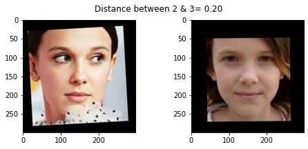

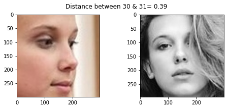

```python
def show_pair(idx1, idx2):
    plt.figure(figsize=(8,3))
    plt.suptitle(f'Distance between {idx1} & {idx2}= {distance(embeddings[idx1], embeddings[idx2]):.2f}')
    plt.subplot(121)
    plt.imshow(load_image(metadata[idx1].image_path()))
    plt.subplot(122)
    plt.imshow(load_image(metadata[idx2].image_path()));

show_pair(2, 3)
show_pair(30, 31)
```

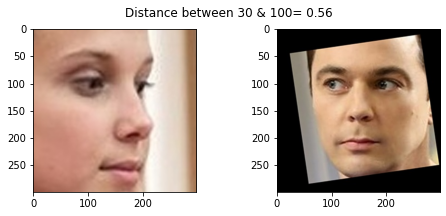

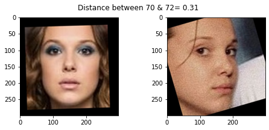

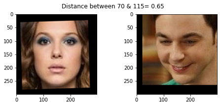

```python
show_pair(30, 100)
show_pair(70, 72)
show_pair(70, 115)
```